# Práctica 3 — Procesamiento Digital de Imágenes

### Fernando León Franco

**Fecha de entrega:** 6 de mayo de 2026

## Resumen

En esta práctica se aplicaron filtros de máscara de convolución para resolver problemas de ruido y mejora de imágenes. La idea fue probar distintas técnicas (pasa-bajas, mediana, gaussiano, high-boost, detección de bordes con laplaciano, resta y promedio de imágenes) y ver cómo se comporta cada una en un caso concreto.

Se empezó viendo qué pasa al aplicar un filtro pasa-bajas un número grande de veces, donde la imagen se va desgastando. Después se trabajó con eliminación de ruido en fotografías reales (torre_verona y las dos de Florencia), donde la mediana resultó ser la mejor opción por cómo trabaja con los cambios bruscos de tono. Más adelante se hizo un barrido con ruido uniforme variando amplitudes y kernels, y se comparó el comportamiento en grises y en RGB.

Luego se aplicó la técnica del high-boost junto con ecualización en una radiografía para ver si el orden importa, y sí: se notan diferencias aunque a simple vista pareciera que no. Después vino la detección de bordes con un laplaciano de 8 vecinos sobre Waldo, donde se probaron distintos pipelines para llegar al trazado en blanco y negro. Finalmente, con las imágenes de la fibra óptica, se hicieron dos análisis: la resta entre dos consecutivas para evaluar el ruido y ver que sigue una distribución normal, y el promedio de 11 imágenes para reducir ese ruido sin perder altas frecuencias.

```python
%matplotlib inline
import sys
from pathlib import Path
import matplotlib.pyplot as plt

BASE_DIR = Path().resolve().parents[1]
sys.path.insert(0, str(BASE_DIR))

from image_processing import DerivativeVisionNode

DATA_DIR = BASE_DIR / "image_processing" / "data"

files = {
    "golf":         "golf.BMP",
    "torre_verona": "ruido/torre_verona.bmp",
    "florencia":    "ruido/florencia.bmp",
    "florencia1":   "ruido/florencia2.bmp",
    "torax":        "toraxP.bmp",
    "waldo":        "waldo.bmp",
}

def load_image(nombre: str) -> DerivativeVisionNode:
    return DerivativeVisionNode.desde_archivo(DATA_DIR / files[nombre])

def load_fibras(n: int = 11) -> list[DerivativeVisionNode]:
    return [
        DerivativeVisionNode.desde_archivo(DATA_DIR / "fibra" / f"fibra3 ({i}).BMP")
        for i in range(1, n + 1)
    ]
```

## 1️⃣ — Ejercicio 1

Aplique el filtrado pasa-bajas varias veces sobre la misma imagen. Explique el resultado limite de aplicar este filtro un numero infinito de veces.

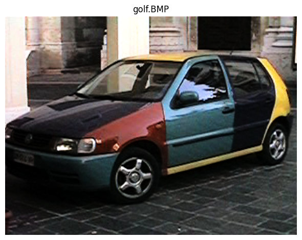

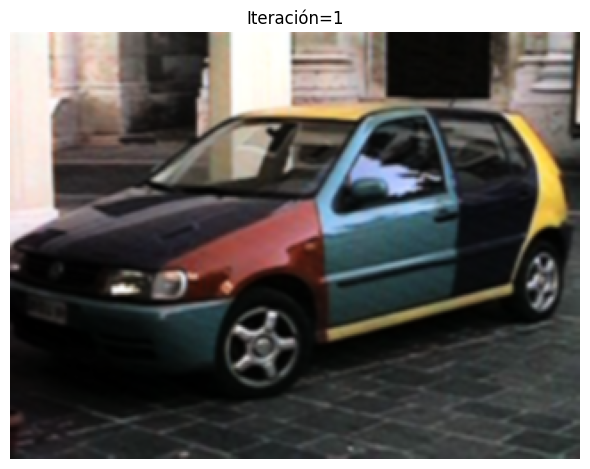

```
Iteración=  1  rango=[0.000, 1.000]
```

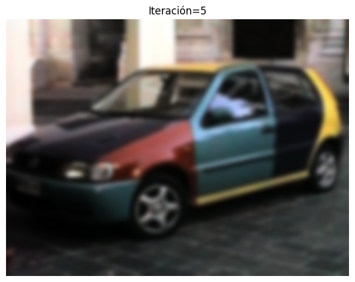

```
Iteración=  5  rango=[0.001, 1.000]
```

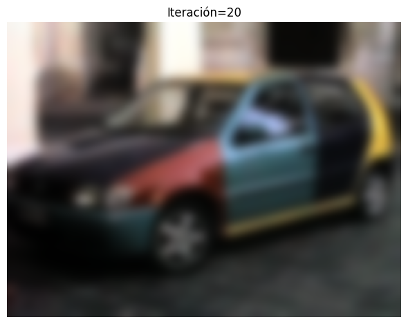

```
Iteración= 20  rango=[0.004, 1.000]
```

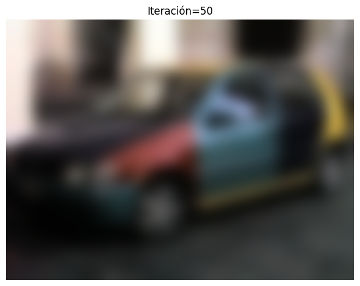

```
Iteración= 50  rango=[0.007, 0.996]
```

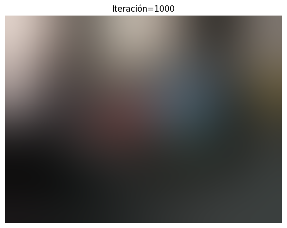

```
Iteración=1000  rango=[0.059, 0.869]
```

```python
imagen = load_image("golf")
imagen.mostrar(block=False)
#imagen.histograma(block=False)

actual = imagen
iteraciones_a_mostrar = (1, 5, 20, 50, 1_000)
for n in range(1, max(iteraciones_a_mostrar) + 1):
    actual = actual.gaussiano(size=5, sigma=1.0)
    if n in iteraciones_a_mostrar:
        actual.title = f"Iteración={n}"
        actual.mostrar(block=False)
        print(f"Iteración={n:3d}  rango=[{actual.min():.3f}, {actual.max():.3f}]")

plt.show()
```

### Explicaciones del Ejercicio 1

**Descripción:**

El ejercicio pide aplicar el filtrado pasa-bajas un número infinito de veces, o al menos así en teoría. Aquí se hizo una iteración hasta 1000 veces y solo se muestran algunas: la primera, la 5, la 20, la 50 y la 1000. La idea es mostrar cuál es la premisa detrás de aplicar el mismo filtro tantas veces y qué tanto se puede hacer en teoría.

Se está usando un kernel gaussiano de tamaño 5 por 5 píxeles, con un sigma de 1 (la desviación estándar).

**¿Cuál es el resultado límite de aplicar el filtro un número infinito de veces?**

Cada filtro lo que hace es promediar los valores de los píxeles con el kernel, pero la cosa es que al aplicarlo una y otra vez, cada iteración nueva trabaja sobre los valores que ya quedaron modificados por la pasada anterior. Es decir, los valores se van moviendo.

A primera vista parece sencillo: uno diría "es el mismo filtro aplicado X veces", pero no es tan simple, porque cada pasada está afectando a la siguiente. El gaussiano tiende a afectar los valores sobre los que pasa el kernel, y entre más pasadas y más pasadas, lo que se ve es como un desgaste sobre la imagen.

Yo lo llamaría así: un desgaste. Sí se pueden aplicar las iteraciones que uno quiera, pero al final lo que vemos es que la imagen se va deteriorando, no mejorando.

## 2️⃣ — Ejercicio 2

Elimine el ruido presente en las fotografias **torre_verona.bmp**, **florencia.bmp** y **florencia1.bmp**. Describa de forma cualitativa y cuantitativa el tipo de ruido presente en la imagen. Justifique el filtro utilizado, asi como los valores de tamaño de ventana, umbral, etc.

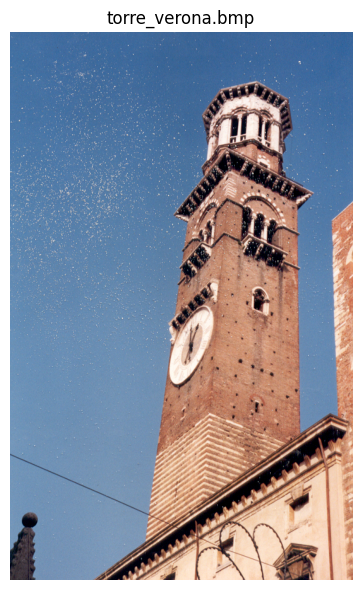

[figure not shown]

[figure not shown]

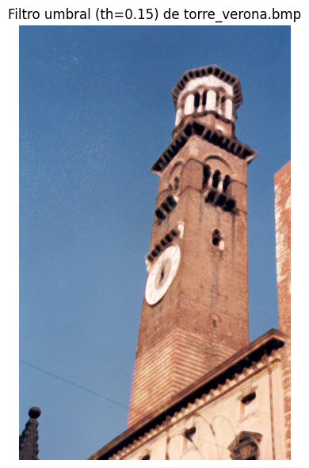

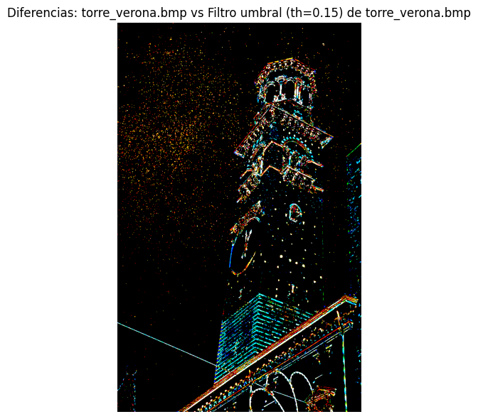

[figure not shown]

[figure not shown]

[figure not shown]

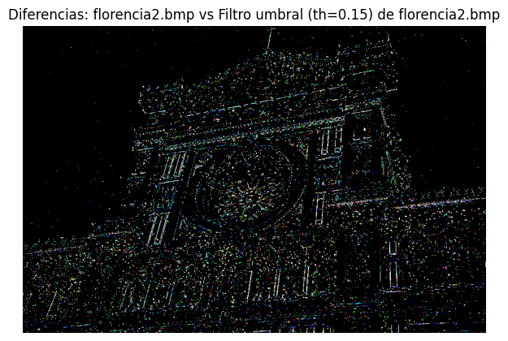

```python
imagen_torre = load_image("torre_verona")
imagen_florencia = load_image("florencia")
imagen_florencia1 = load_image("florencia1")

for img in (imagen_torre, imagen_florencia, imagen_florencia1):
    img.mostrar(block=False)


aplificacion = 5.0
umbral = 0.15


# Torre de Verona
mediana_tamaño = 9
torre_filt = imagen_torre.mediana(size=mediana_tamaño)
torre_limpia = imagen_torre.filtro_umbral(torre_filt, umbral=umbral)
torre_limpia.mostrar(block=False)
imagen_torre.mostrar_diferencias(torre_limpia, magnifier=aplificacion, block=False)

#  Florencia
mediana_tamaño = 5
florencia_limpia = imagen_florencia.mediana(size=mediana_tamaño)
florencia_limpia.mostrar(block=False)
imagen_florencia.mostrar_diferencias(florencia_limpia, magnifier=aplificacion, block=False)

# Florencia 1
mediana_tamaño = 5
florencia1_filt = imagen_florencia1.mediana(size=mediana_tamaño)
florencia1_limpia = imagen_florencia1.filtro_umbral(florencia1_filt, umbral=umbral)
florencia1_limpia.mostrar(block=False)
imagen_florencia1.mostrar_diferencias(florencia1_limpia, magnifier=aplificacion, block=False)

plt.show()
```

### Explicaciones del Ejercicio 2

**Descripción:**

En este ejercicio hay que entender qué está pasando con el ruido de cada imagen, de forma cualitativa y cuantitativa, y justificar los valores y tamaños de las ventanas que se usan.

**Torre de Verona:**

Aquí tenemos un problema con la imagen. Parece ser que hay un tipo de ruido sal y pimienta, pero con tamaños diferentes. Me explico: hay un área en la parte superior izquierda donde se ven píxeles blancos agrupados, como si fuera un sprite. El problema es que algunos píxeles son un poco más grandes que otros, y eso sí afecta al kernel.

Aplicando una mediana de tamaño 9, es suficiente para dejar la imagen lo suficientemente limpia. Pero pasa una cosa: la mediana no solo está afectando a los píxeles blancos del ruido, sino que también está promediando y modificando la definición de la torre, dejándola un poco plasticosa y quitándole nitidez.

**Florencia (la primera):**

Aquí pasa algo parecido. También hay píxeles blancos pequeños distribuidos por toda la imagen. Casi no se alcanzan a ver porque Florencia tiene mucha área blanca, así que el ruido se confunde con el fondo. Donde sí se nota es en las zonas más oscuras: las estatuas, los bordes, las esquinas y las zonas con sombra.

Para distinguirlos bien, lo que ayuda es hacer la resta entre la original y la filtrada y amplificar las diferencias. Ahí sí se ven cuáles son los píxeles más afectados, y se puede confirmar que el ruido sí está ahí.

**Florencia 2:**

**¿Por qué mediana y no otro tipo de filtro?**

Podríamos poner un filtro gaussiano o un filtro pasa-bajos, pero hay que recordar la premisa de la mediana. La mediana, por su distribución, detecta bien los cambios de tono entre píxeles. Esto la hace ideal cuando hay segmentos de píxeles juntos de tonos muy drásticos contra los píxeles laterales, porque ahí es donde la mediana entiende cuál es el valor representativo de la zona donde pasa el kernel.

En estadística, la mediana es donde se encuentran la mayoría de los valores. Por eso no tiene mucho sentido forzar la imagen con un gaussiano, que es básicamente un promedio o distribución, cuando la mediana ya nos está dando un dato más sólido.

Aplicando un kernel un poquito más agresivo, en este caso un 5 por 5 tanto en Florencia 1 como en Florencia 2, se logra reducir bien el ruido. Esto se alcanza a distinguir cuando hacemos la resta entre las dos imágenes en este ejercicio.

## 3️⃣ — Ejercicio 3

Utilizando un generador de ruido uniforme, pruebe el filtro de mediana con distintos valores de radio y porcentajes de ruido, en tonos de grises y en RGB. En base a sus pruebas ¿es posible establecer una relacion entre porcentaje de ruido y radio de mascara de filtrado? Explique.

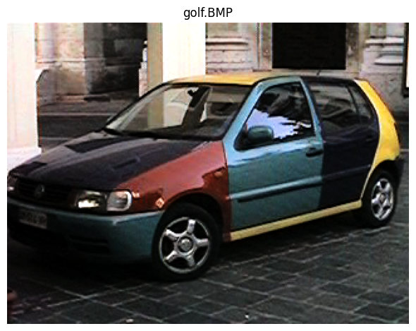

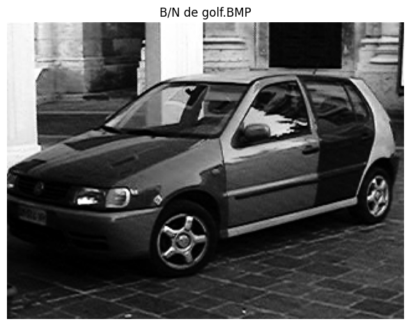

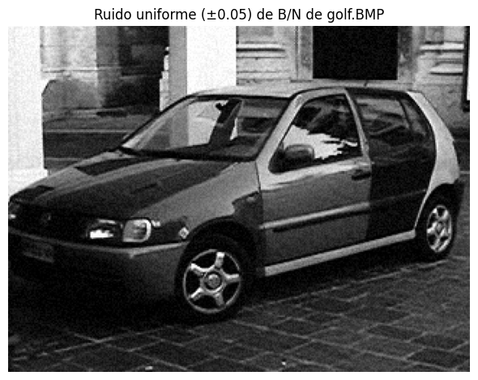

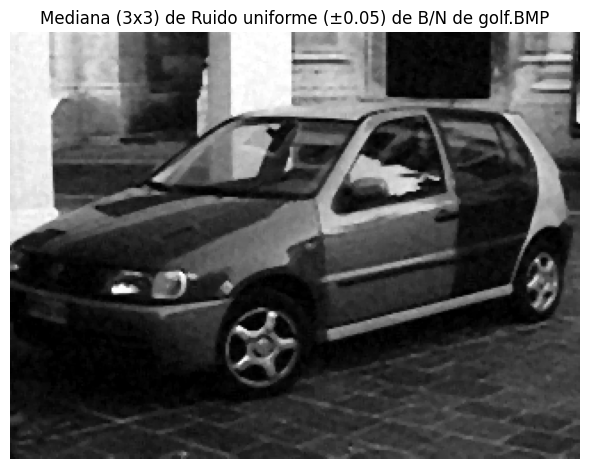

```
grises amp=0.05 size=3 → error_medio=0.0243
```

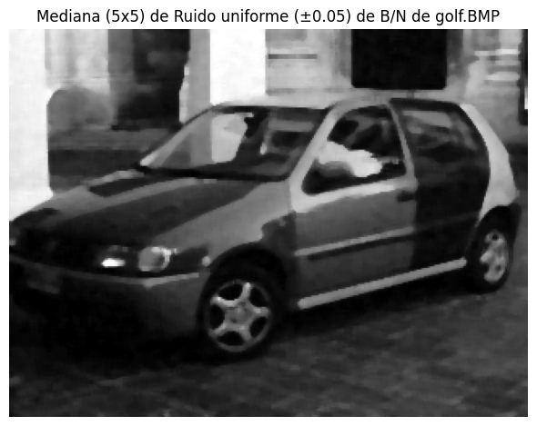

```
grises amp=0.05 size=5 → error_medio=0.0359
```

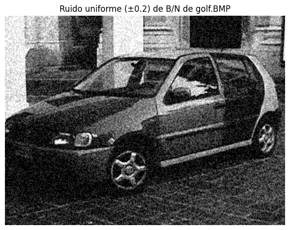

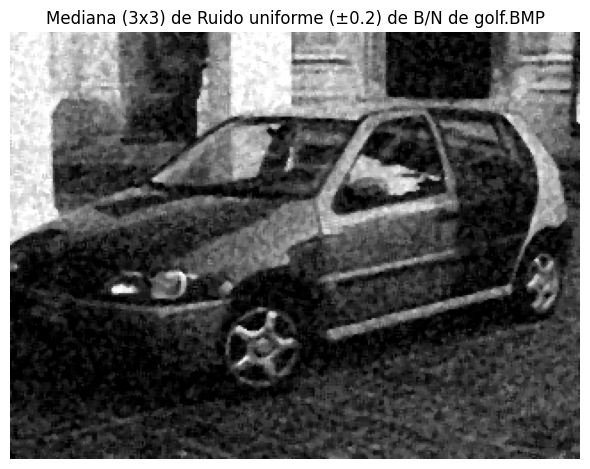

```
grises amp=0.20 size=3 → error_medio=0.0538
```

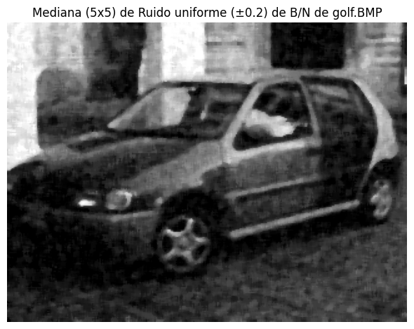

```
grises amp=0.20 size=5 → error_medio=0.0536
```

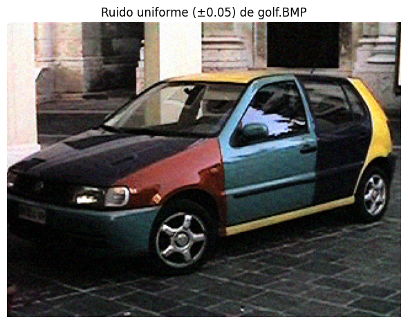

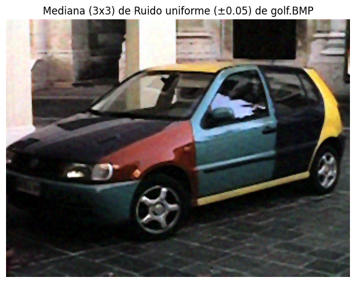

```
color  amp=0.05 size=3 → error_medio=0.0246
```

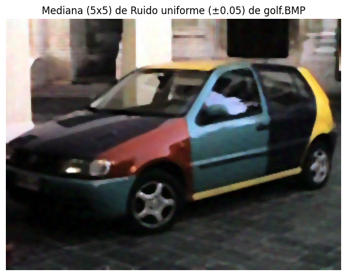

```
color  amp=0.05 size=5 → error_medio=0.0364
```

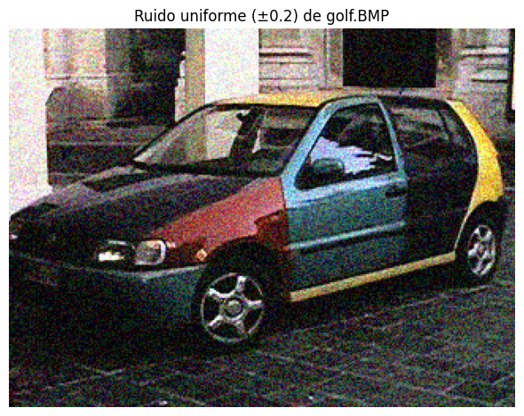

[2 more figures not shown]

```
color  amp=0.20 size=5 → error_medio=0.0539
```

```python
imagen_color  = load_image("golf")
imagen_grises = imagen_color.escala_grises()
imagen_color.mostrar(block=False)
imagen_grises.mostrar(block=False)

amplitudes = (0.05, 0.20)
tamaños = (3, 5)

for base, etiqueta in [(imagen_grises, "grises"), (imagen_color, "color")]:
    for amp in amplitudes:
        ruidosa = base.ruido_uniforme(amplitud=amp, seed=42)
        ruidosa.mostrar(block=False)
        for s in tamaños:
            filtrada = ruidosa.mediana(size=s)
            filtrada.mostrar(block=False)
            error = (base.tensor - filtrada.tensor).abs().mean().item()
            print(f"{etiqueta:6s} amp={amp:.2f} size={s} → error_medio={error:.4f}")

plt.show()
```